# EDA_Outage

```
Shape: (3200875, 23)
```

|  | state | county | cvi_overall | cvi_baseline_all | cvi_baseline_health | cvi_baseline_social_econ | cvi_baseline_infra | cvi_baseline_env | cvi_climate_all | cvi_climate_health | ... | county_fips | outage_year | outage_start_time | outage_duration_hours | outage_min_customers | outage_max_customers | outage_mean_customers | outage_event_type | outage_end_time | outage_event_uid |
| --- | --- | --- | --- | --- | --- | --- | --- | --- | --- | --- | --- | --- | --- | --- | --- | --- | --- | --- | --- | --- | --- |
| 0 | NY | Bronx | 0.535334 | 0.550426 | 0.642327 | 0.572482 | 0.369538 | 0.617356 | 0.515212 | 0.416614 | ... | 36005 | 2014 | 2014-11-02 22:15:00 | 0.75 | 708.0 | 708.0 | 708.000000 | NaN | NaN | 2014_7089 |
| 1 | NY | Bronx | 0.535334 | 0.550426 | 0.642327 | 0.572482 | 0.369538 | 0.617356 | 0.515212 | 0.416614 | ... | 36005 | 2014 | 2014-11-04 14:30:00 | 1.50 | 297.0 | 701.0 | 364.333333 | NaN | NaN | 2014_7090 |
| 2 | NY | Bronx | 0.535334 | 0.550426 | 0.642327 | 0.572482 | 0.369538 | 0.617356 | 0.515212 | 0.416614 | ... | 36005 | 2014 | 2014-11-04 21:00:00 | 0.25 | 296.0 | 296.0 | 296.000000 | NaN | NaN | 2014_7091 |
| 3 | NY | Bronx | 0.535334 | 0.550426 | 0.642327 | 0.572482 | 0.369538 | 0.617356 | 0.515212 | 0.416614 | ... | 36005 | 2014 | 2014-12-04 20:45:00 | 1.25 | 481.0 | 481.0 | 481.000000 | NaN | NaN | 2014_7092 |
| 4 | NY | Bronx | 0.535334 | 0.550426 | 0.642327 | 0.572482 | 0.369538 | 0.617356 | 0.515212 | 0.416614 | ... | 36005 | 2014 | 2014-12-24 00:30:00 | 1.75 | 204.0 | 265.0 | 256.285714 | NaN | NaN | 2014_7093 |

5 rows × 23 columns

```
Columns:
['state', 'county', 'cvi_overall', 'cvi_baseline_all', 'cvi_baseline_health', 'cvi_baseline_social_econ', 'cvi_baseline_infra', 'cvi_baseline_env', 'cvi_climate_all', 'cvi_climate_health', 'cvi_climate_social_econ', 'cvi_climate_extreme_events', 'tract_fips', 'county_fips', 'outage_year', 'outage_st…
```

```
Rows after NYC filter: 3200875
Valid datetime rows: 3200875
Unique NYC counties in data: ['36005', '36047', '36061', '36081', '36085']
Unique tracts: 2168
```

|  | year | total_outages | severe_weather_outages | severe_weather_share | avg_duration_hours |
| --- | --- | --- | --- | --- | --- |
| 0 | 2014 | 17171 | 0 | 0.000 | 1.75 |
| 1 | 2015 | 280690 | 0 | 0.000 | 4.11 |
| 2 | 2016 | 296277 | 0 | 0.000 | 2.91 |
| 3 | 2017 | 227010 | 1560 | 0.007 | 3.35 |
| 4 | 2018 | 667269 | 215400 | 0.323 | 3.60 |
| 5 | 2019 | 306579 | 53248 | 0.174 | 4.08 |
| 6 | 2020 | 274108 | 29933 | 0.109 | 7.98 |
| 7 | 2021 | 319416 | 444 | 0.001 | 4.12 |
| 8 | 2022 | 587220 | 117283 | 0.200 | 2.10 |
| 9 | 2023 | 225135 | 3024 | 0.013 | 2.25 |

## Build FIPS-Year Panel

```
NYC tract-year panel shape: (20993, 6)
Unique tracts in panel: 2168
```

|  | tract_fips | county_fips | year | outage_occurrence | severe_weather_count | outage_duration_mean |
| --- | --- | --- | --- | --- | --- | --- |
| 0 | 36005000100 | 36005 | 2014 | 6 | 0 | 1.12 |
| 1 | 36005000100 | 36005 | 2015 | 72 | 0 | 1.66 |
| 2 | 36005000100 | 36005 | 2016 | 123 | 0 | 2.07 |
| 3 | 36005000100 | 36005 | 2017 | 64 | 0 | 2.24 |
| 4 | 36005000100 | 36005 | 2018 | 304 | 137 | 4.25 |
| 5 | 36005000100 | 36005 | 2019 | 113 | 38 | 2.52 |
| 6 | 36005000100 | 36005 | 2020 | 120 | 11 | 9.59 |
| 7 | 36005000100 | 36005 | 2021 | 109 | 0 | 4.14 |
| 8 | 36005000100 | 36005 | 2022 | 217 | 61 | 2.16 |
| 9 | 36005000100 | 36005 | 2023 | 113 | 3 | 1.92 |
| 10 | 36005000200 | 36005 | 2014 | 6 | 0 | 1.12 |
| 11 | 36005000200 | 36005 | 2015 | 72 | 0 | 1.66 |
| 12 | 36005000200 | 36005 | 2016 | 123 | 0 | 2.07 |
| 13 | 36005000200 | 36005 | 2017 | 64 | 0 | 2.24 |
| 14 | 36005000200 | 36005 | 2018 | 304 | 137 | 4.25 |
| 15 | 36005000200 | 36005 | 2019 | 113 | 38 | 2.52 |
| 16 | 36005000200 | 36005 | 2020 | 120 | 11 | 9.59 |
| 17 | 36005000200 | 36005 | 2021 | 109 | 0 | 4.14 |
| 18 | 36005000200 | 36005 | 2022 | 217 | 61 | 2.16 |
| 19 | 36005000200 | 36005 | 2023 | 113 | 3 | 1.92 |

## 1) Severe Weather vs Outage Occurrence/Duration (Per FIPS)

```
Significant tracts: 1769
```

|  | tract_fips | beta | p |
| --- | --- | --- | --- |
| 20 | 36005004200 | 1.673571 | 0.000405 |
| 19 | 36005004100 | 1.673571 | 0.000405 |
| 18 | 36005004001 | 1.673571 | 0.000405 |
| 17 | 36005003900 | 1.673571 | 0.000405 |
| 16 | 36005003800 | 1.673571 | 0.000405 |
| 15 | 36005003700 | 1.673571 | 0.000405 |
| 14 | 36005003500 | 1.673571 | 0.000405 |
| 13 | 36005003300 | 1.673571 | 0.000405 |
| 12 | 36005003100 | 1.673571 | 0.000405 |
| 11 | 36005002800 | 1.673571 | 0.000405 |
| 10 | 36005002702 | 1.673571 | 0.000405 |
| 9 | 36005002701 | 1.673571 | 0.000405 |
| 8 | 36005002500 | 1.673571 | 0.000405 |
| 31 | 36005005600 | 1.673571 | 0.000405 |
| 30 | 36005005400 | 1.673571 | 0.000405 |
| 29 | 36005005300 | 1.673571 | 0.000405 |
| 47 | 36005007500 | 1.673571 | 0.000405 |
| 46 | 36005007400 | 1.673571 | 0.000405 |
| 45 | 36005007300 | 1.673571 | 0.000405 |
| 44 | 36005007200 | 1.673571 | 0.000405 |

## 2) Outage Occurrence/Duration Trend Over Years (Per FIPS)

The `nvSRwVGPbmuu` cell iterates through each `tract_fips` and performs OLS regression against the `year` column for both `outage_occurrence` and `outage_duration_mean` (after log transformation for duration). It then calculates significance flags and trend directions based on the results.

```
Tracts with >= min_years: 2168
Significant tract trend (occurrence, p<0.05): 0
Significant tract trend (duration-log, p<0.05): 0
Occurrence trend direction counts:
```

|  | occ_trend_dir | n_tracts |
| --- | --- | --- |
| 0 | no_sig_trend | 2168 |

```
Duration trend direction counts:
```

|  | dur_trend_dir | n_tracts |
| --- | --- | --- |
| 0 | no_sig_trend | 2168 |

[output not shown]

[output not shown]

[output not shown]

[output not shown]

```
Tracts: 2168
Significant tract trend (occurrence, p<0.05): 0
Significant tract trend (duration-log, p<0.05): 0
Occurrence trend direction counts:
```

|  | occ_trend_dir | n_tracts |
| --- | --- | --- |
| 0 | no_sig_trend | 2168 |

```
Duration trend direction counts:
```

|  | dur_trend_dir | n_tracts |
| --- | --- | --- |
| 0 | no_sig_trend | 2168 |

## 3) Month Effect in Each Year

Method: Chi-square goodness-of-fit per year, with expected monthly outages proportional to days in month. Then identify significantly high months by standardized residuals (FDR-corrected).

```
Years with significant month effect: 10

Year-level test results:
```

|  | year | total_outages | chi2_stat | chi2_p | chi2_q | year_has_month_effect_sig_05 |
| --- | --- | --- | --- | --- | --- | --- |
| 0 | 2014 | 17171 | 1.004844e+05 | 0.0 | 0.0 | True |
| 1 | 2015 | 280690 | 1.030069e+05 | 0.0 | 0.0 | True |
| 2 | 2016 | 296277 | 1.641799e+05 | 0.0 | 0.0 | True |
| 3 | 2017 | 227010 | 3.511924e+04 | 0.0 | 0.0 | True |
| 4 | 2018 | 667269 | 1.092333e+06 | 0.0 | 0.0 | True |
| 5 | 2019 | 306579 | 1.388598e+05 | 0.0 | 0.0 | True |
| 6 | 2020 | 274108 | 1.346133e+05 | 0.0 | 0.0 | True |
| 7 | 2021 | 319416 | 7.494578e+04 | 0.0 | 0.0 | True |
| 8 | 2022 | 587220 | 1.786282e+05 | 0.0 | 0.0 | True |
| 9 | 2023 | 225135 | 4.323207e+04 | 0.0 | 0.0 | True |

```
Most extreme significantly high month per year (if exists):
```

|  | year | month | obs_count | std_resid | resid_q |
| --- | --- | --- | --- | --- | --- |
| 0 | 2014 | 11 | 11715 | 274.271436 | 0.0 |
| 1 | 2015 | 6 | 48404 | 166.789634 | 0.0 |
| 2 | 2016 | 9 | 77368 | 340.632754 | 0.0 |
| 3 | 2017 | 3 | 36381 | 123.156388 | 0.0 |
| 4 | 2018 | 3 | 241848 | 777.856402 | 0.0 |
| 5 | 2019 | 7 | 74972 | 303.251655 | 0.0 |
| 6 | 2020 | 7 | 62749 | 259.447714 | 0.0 |
| 7 | 2021 | 2 | 56325 | 203.289325 | 0.0 |
| 8 | 2022 | 4 | 123690 | 343.322824 | 0.0 |
| 9 | 2023 | 7 | 37758 | 134.777937 | 0.0 |

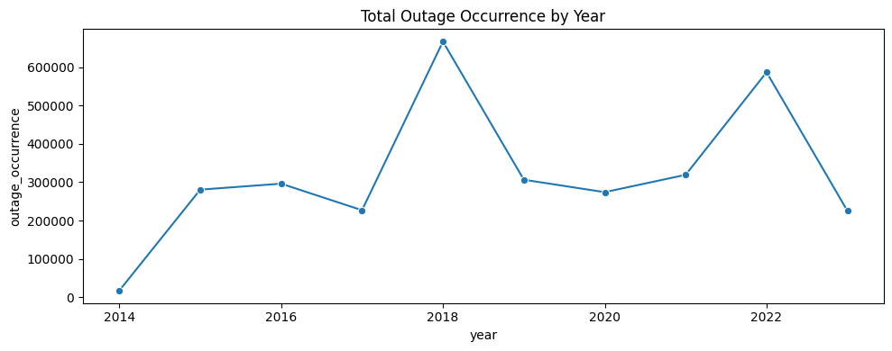

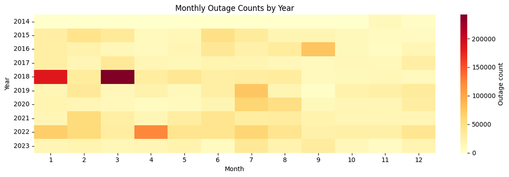

## 4) Result Visualizations (Effect Size + Significance)

```
Significant tracts (SW vs Occurrence): 1008
Significant tracts (SW vs Duration): 0
```

|  | tract_fips | n_years | occ_spearman_rho | occ_spearman_p | dur_spearman_rho | dur_spearman_p | occ_spearman_q | dur_spearman_q | occ_sig_05 | dur_sig_05 |
| --- | --- | --- | --- | --- | --- | --- | --- | --- | --- | --- |
| 0 | 36005000100 | 10 | 0.758717 | 0.010951 | 0.510741 | 0.131413 | 0.023554 | 0.454391 | True | False |
| 1 | 36005000200 | 10 | 0.758717 | 0.010951 | 0.510741 | 0.131413 | 0.023554 | 0.454391 | True | False |
| 2 | 36005000400 | 10 | 0.758717 | 0.010951 | 0.510741 | 0.131413 | 0.023554 | 0.454391 | True | False |
| 3 | 36005001600 | 10 | 0.758717 | 0.010951 | 0.510741 | 0.131413 | 0.023554 | 0.454391 | True | False |
| 4 | 36005001900 | 10 | 0.758717 | 0.010951 | 0.510741 | 0.131413 | 0.023554 | 0.454391 | True | False |

## 5) Additional Method: Month-by-Month Trend Over Years (NYC overall)

Different from the month-effect test in Goal 3, this checks whether **January itself is increasing/decreasing over years**, and similarly for each month.

|  | month | month_name | occ_tau | occ_slope_per_year | occ_q | occ_sig_05 | dur_tau | dur_log_slope_per_year | dur_q | dur_sig_05 |
| --- | --- | --- | --- | --- | --- | --- | --- | --- | --- | --- |
| 0 | 1 | Jan | -0.388889 | -1791.687500 | 0.520046 | False | -0.777778 | -0.140654 | 0.029101 | True |
| 1 | 2 | Feb | 0.166667 | 1014.333333 | 0.612202 | False | -0.222222 | -0.052295 | 0.635611 | False |
| 2 | 3 | Mar | -0.222222 | -970.857143 | 0.520046 | False | -0.388889 | -0.128008 | 0.537731 | False |
| 3 | 4 | Apr | 0.222222 | 918.142857 | 0.520046 | False | -0.277778 | -0.034196 | 0.537731 | False |
| 4 | 5 | May | 0.222222 | 945.645833 | 0.520046 | False | -0.500000 | -0.048581 | 0.451058 | False |
| 5 | 6 | Jun | -0.277778 | -2320.833333 | 0.520046 | False | 0.000000 | -0.002992 | 1.000000 | False |
| 6 | 7 | Jul | 0.277778 | 2521.214286 | 0.520046 | False | -0.277778 | -0.031677 | 0.537731 | False |
| 7 | 8 | Aug | 0.222222 | 1418.916667 | 0.520046 | False | 0.277778 | 0.040895 | 0.537731 | False |
| 8 | 9 | Sep | 0.222222 | 1468.187500 | 0.520046 | False | 0.166667 | 0.055342 | 0.667857 | False |
| 9 | 10 | Oct | 0.500000 | 870.566667 | 0.451058 | False | -0.166667 | -0.016369 | 0.667857 | False |
| 10 | 11 | Nov | 0.333333 | 878.750000 | 0.520046 | False | 0.377778 | 0.024565 | 0.537731 | False |
| 11 | 12 | Dec | 0.555556 | 2083.000000 | 0.343313 | False | 0.288889 | 0.021450 | 0.537731 | False |

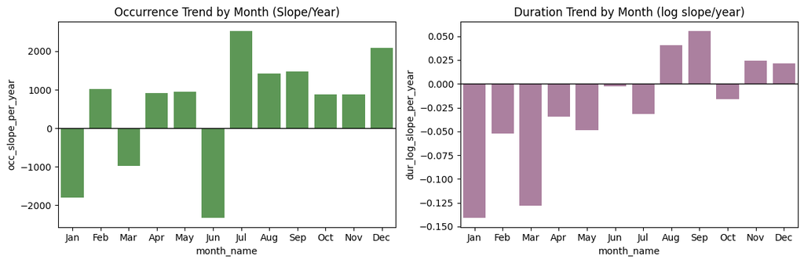

## 6) Additional Method: Tract Seasonality Clustering

Pattern discovery method: cluster tracts by their monthly outage profile (share of outages in each month). This can reveal groups of tracts with distinct seasonal behavior even when significance tests are weak.

|  | cluster | n_tracts |
| --- | --- | --- |
| 0 | 0 | 111 |
| 1 | 1 | 1008 |
| 2 | 2 | 288 |
| 3 | 3 | 761 |

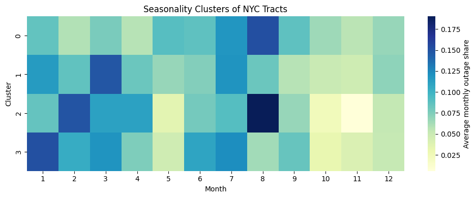

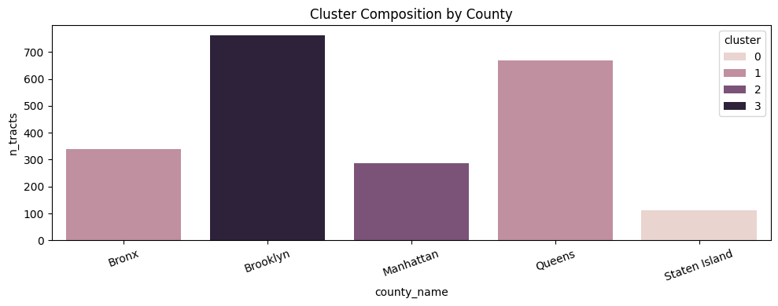

```
cluster
1    1008
3     761
2     288
0     111
Name: count, dtype: int64
county_name    cluster
Bronx          1          339
Brooklyn       3          761
Manhattan      2          288
Queens         1          669
Staten Island  0          111
Name: count, dtype: int64
```

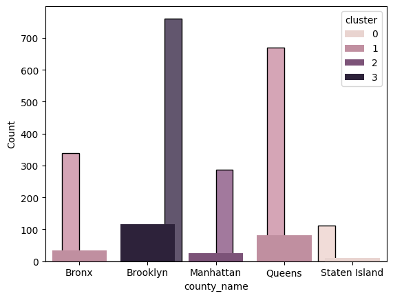

## 7) Add CVI Variables: Trend Slope Distribution + Exploratory Regression

This section starts to bring the CVI fields into the tract-year analysis. It does three things:

1. builds a tract-level CVI table from `Outage_CVI_Events.csv`,
2. looks at the distribution of tract trend slopes, and
3. runs a few exploratory regression specifications with interactions and nonlinear terms.

```
Available CVI columns:
['cvi_overall', 'cvi_baseline_all', 'cvi_baseline_health', 'cvi_baseline_social_econ', 'cvi_baseline_infra', 'cvi_baseline_env', 'cvi_climate_all', 'cvi_climate_health', 'cvi_climate_social_econ', 'cvi_climate_extreme_events']
```

|  | tract_fips | n_years | occ_slope_per_year | occ_p | dur_log_slope_per_year | dur_p | occ_trend_sig_05 | dur_trend_sig_05 | occ_trend_dir | dur_trend_dir | ... | cvi_overall | cvi_baseline_all | cvi_baseline_health | cvi_baseline_social_econ | cvi_baseline_infra | cvi_baseline_env | cvi_climate_all | cvi_climate_health | cvi_climate_social_econ | cvi_climate_extreme_events |
| --- | --- | --- | --- | --- | --- | --- | --- | --- | --- | --- | --- | --- | --- | --- | --- | --- | --- | --- | --- | --- | --- |
| 0 | 36005000100 | 10 | 11.424242 | 0.229903 | 0.059499 | 0.261187 | False | False | no_sig_trend | no_sig_trend | ... | 0.535334 | 0.550426 | 0.642327 | 0.572482 | 0.369538 | 0.617356 | 0.515212 | 0.416614 | 0.526831 | 0.602192 |
| 1 | 36005000200 | 10 | 11.424242 | 0.229903 | 0.059499 | 0.261187 | False | False | no_sig_trend | no_sig_trend | ... | 0.557262 | 0.618647 | 0.536897 | 0.807660 | 0.583026 | 0.547004 | 0.475415 | 0.428630 | 0.440171 | 0.557442 |
| 2 | 36005000400 | 10 | 11.424242 | 0.229903 | 0.059499 | 0.261187 | False | False | no_sig_trend | no_sig_trend | ... | 0.526520 | 0.540622 | 0.469100 | 0.612295 | 0.548589 | 0.532504 | 0.507718 | 0.430387 | 0.507025 | 0.585742 |
| 3 | 36005001600 | 10 | 11.424242 | 0.229903 | 0.059499 | 0.261187 | False | False | no_sig_trend | no_sig_trend | ... | 0.577907 | 0.670849 | 0.632347 | 0.826614 | 0.607396 | 0.617041 | 0.453984 | 0.437604 | 0.422238 | 0.502111 |
| 4 | 36005001900 | 10 | 11.424242 | 0.229903 | 0.059499 | 0.261187 | False | False | no_sig_trend | no_sig_trend | ... | 0.594053 | 0.649981 | 0.578240 | 0.805831 | 0.457360 | 0.758491 | 0.519482 | 0.476253 | 0.491076 | 0.591116 |

5 rows × 26 columns

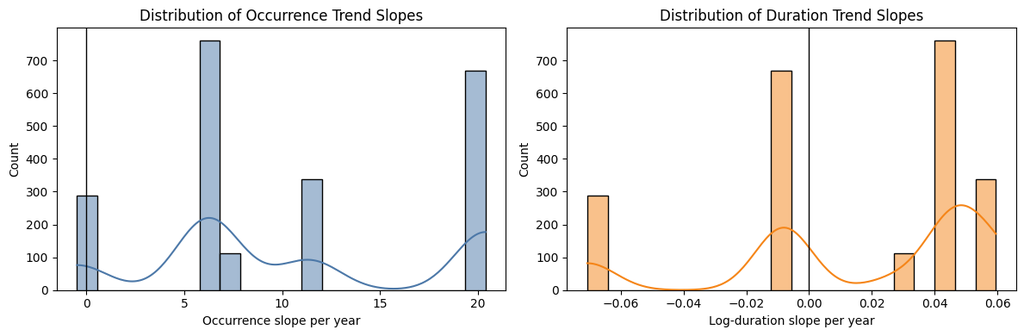

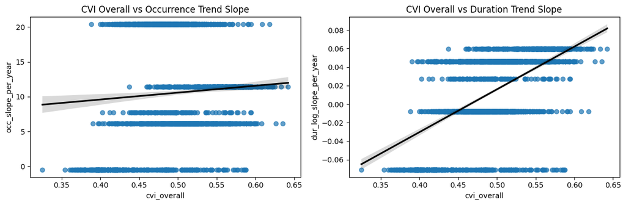

|  | cvi_variable | outcome | n | spearman_rho | p_value | abs_rho |
| --- | --- | --- | --- | --- | --- | --- |
| 19 | cvi_baseline_infra | dur_log_slope_per_year | 2168 | 0.641223 | 2.128960e-251 | 0.641223 |
| 3 | cvi_overall | dur_log_slope_per_year | 2168 | 0.561802 | 1.287930e-180 | 0.561802 |
| 7 | cvi_baseline_all | dur_log_slope_per_year | 2168 | 0.557022 | 5.956850e-177 | 0.557022 |
| 11 | cvi_baseline_health | dur_log_slope_per_year | 2168 | 0.491342 | 3.849304e-132 | 0.491342 |
| 15 | cvi_baseline_social_econ | dur_log_slope_per_year | 2168 | 0.478846 | 1.132958e-124 | 0.478846 |
| 33 | cvi_climate_social_econ | avg_duration_hours | 2168 | 0.401617 | 7.890874e-85 | 0.401617 |
| 38 | cvi_climate_extreme_events | occ_slope_per_year | 2168 | -0.348585 | 5.709263e-63 | 0.348585 |
| 36 | cvi_climate_extreme_events | avg_outage_occurrence | 2168 | -0.313508 | 1.188174e-50 | 0.313508 |
| 32 | cvi_climate_social_econ | avg_outage_occurrence | 2168 | 0.294988 | 8.763904e-45 | 0.294988 |
| 37 | cvi_climate_extreme_events | avg_duration_hours | 2168 | 0.264237 | 5.845735e-36 | 0.264237 |
| 17 | cvi_baseline_infra | avg_duration_hours | 2168 | 0.233852 | 2.571439e-28 | 0.233852 |
| 35 | cvi_climate_social_econ | dur_log_slope_per_year | 2168 | 0.214114 | 6.710676e-24 | 0.214114 |
| 25 | cvi_climate_all | avg_duration_hours | 2168 | 0.201722 | 2.429157e-21 | 0.201722 |
| 14 | cvi_baseline_social_econ | occ_slope_per_year | 2168 | 0.189981 | 4.573713e-19 | 0.189981 |
| 29 | cvi_climate_health | avg_duration_hours | 2168 | -0.164533 | 1.266876e-14 | 0.164533 |
| 30 | cvi_climate_health | occ_slope_per_year | 2168 | 0.157466 | 1.659462e-13 | 0.157466 |
| 1 | cvi_overall | avg_duration_hours | 2168 | 0.154184 | 5.270467e-13 | 0.154184 |
| 26 | cvi_climate_all | occ_slope_per_year | 2168 | -0.147153 | 5.768162e-12 | 0.147153 |
| 20 | cvi_baseline_env | avg_outage_occurrence | 2168 | -0.130168 | 1.177695e-09 | 0.130168 |
| 5 | cvi_baseline_all | avg_duration_hours | 2168 | 0.110747 | 2.346901e-07 | 0.110747 |
| 22 | cvi_baseline_env | occ_slope_per_year | 2168 | -0.107186 | 5.664415e-07 | 0.107186 |
| 28 | cvi_climate_health | avg_outage_occurrence | 2168 | 0.106758 | 6.285201e-07 | 0.106758 |
| 6 | cvi_baseline_all | occ_slope_per_year | 2168 | 0.106665 | 6.428540e-07 | 0.106665 |
| 10 | cvi_baseline_health | occ_slope_per_year | 2168 | 0.105329 | 8.870612e-07 | 0.105329 |
| 34 | cvi_climate_social_econ | occ_slope_per_year | 2168 | -0.102420 | 1.764404e-06 | 0.102420 |
| 8 | cvi_baseline_health | avg_outage_occurrence | 2168 | -0.083373 | 1.016941e-04 | 0.083373 |
| 0 | cvi_overall | avg_outage_occurrence | 2168 | -0.080768 | 1.667520e-04 | 0.080768 |
| 23 | cvi_baseline_env | dur_log_slope_per_year | 2168 | -0.077317 | 3.141511e-04 | 0.077317 |
| 9 | cvi_baseline_health | avg_duration_hours | 2168 | 0.065729 | 2.198574e-03 | 0.065729 |
| 2 | cvi_overall | occ_slope_per_year | 2168 | 0.063354 | 3.166236e-03 | 0.063354 |
| 4 | cvi_baseline_all | avg_outage_occurrence | 2168 | -0.049859 | 2.025396e-02 | 0.049859 |
| 18 | cvi_baseline_infra | occ_slope_per_year | 2168 | 0.047820 | 2.597595e-02 | 0.047820 |
| 31 | cvi_climate_health | dur_log_slope_per_year | 2168 | -0.045643 | 3.357943e-02 | 0.045643 |
| 16 | cvi_baseline_infra | avg_outage_occurrence | 2168 | -0.038258 | 7.491342e-02 | 0.038258 |
| 24 | cvi_climate_all | avg_outage_occurrence | 2168 | 0.031746 | 1.394986e-01 | 0.031746 |
| 21 | cvi_baseline_env | avg_duration_hours | 2168 | 0.016291 | 4.483689e-01 | 0.016291 |
| 27 | cvi_climate_all | dur_log_slope_per_year | 2168 | -0.015641 | 4.666798e-01 | 0.015641 |
| 39 | cvi_climate_extreme_events | dur_log_slope_per_year | 2168 | -0.012322 | 5.663462e-01 | 0.012322 |
| 12 | cvi_baseline_social_econ | avg_outage_occurrence | 2168 | 0.005944 | 7.820783e-01 | 0.005944 |
| 13 | cvi_baseline_social_econ | avg_duration_hours | 2168 | -0.001010 | 9.625125e-01 | 0.001010 |

```
Regression CVI terms: cvi_overall cvi_baseline_social_econ cvi_climate_extreme_events
```

|  | outcome | model | formula | nobs | r_squared | adj_r_squared | aic | bic |
| --- | --- | --- | --- | --- | --- | --- | --- | --- |
| 0 | Occurrence | occ_linear | outage_occurrence ~ year_centered + severe_wea... | 20993 | 0.650609 | 0.650559 | 236501.937778 | 236533.745555 |
| 1 | Occurrence | occ_interaction | outage_occurrence ~ year_centered + severe_wea... | 20993 | 0.659810 | 0.659729 | 235945.681613 | 235993.393279 |
| 2 | Occurrence | occ_nonlinear | outage_occurrence ~ year_centered + severe_wea... | 20993 | 0.684456 | 0.684380 | 234366.930288 | 234414.641954 |
| 3 | Log duration | dur_linear | log_outage_duration_mean ~ year_centered + sev... | 20993 | 0.016812 | 0.016672 | 24222.372228 | 24254.180005 |
| 4 | Log duration | dur_interaction | log_outage_duration_mean ~ year_centered + sev... | 20993 | 0.020161 | 0.019928 | 24154.739556 | 24202.451222 |
| 5 | Log duration | dur_nonlinear | log_outage_duration_mean ~ year_centered + sev... | 20993 | 0.019897 | 0.019663 | 24160.410851 | 24208.122517 |

|  | outcome | model | term | coef | p_value | abs_coef |
| --- | --- | --- | --- | --- | --- | --- |
| 24 | Log duration | dur_nonlinear | I(cvi_overall ** 2) | -3.084051 | 6.415260e-04 | 3.084051 |
| 23 | Log duration | dur_nonlinear | cvi_overall | 2.806926 | 1.774631e-03 | 2.806926 |
| 18 | Log duration | dur_interaction | cvi_climate_extreme_events | -0.237046 | 1.404888e-11 | 0.237046 |
| 20 | Log duration | dur_interaction | cvi_baseline_social_econ | -0.131562 | 2.034576e-09 | 0.131562 |
| 21 | Log duration | dur_nonlinear | year_centered | 0.019700 | 4.654745e-78 | 0.019700 |
| 13 | Log duration | dur_linear | year_centered | 0.019636 | 2.110951e-77 | 0.019636 |
| 16 | Log duration | dur_interaction | year_centered | 0.019530 | 8.653707e-77 | 0.019530 |
| 15 | Log duration | dur_linear | cvi_overall | -0.017217 | 7.750111e-01 | 0.017217 |
| 25 | Log duration | dur_nonlinear | severe_weather_count:cvi_overall | 0.013279 | 1.486614e-14 | 0.013279 |
| 22 | Log duration | dur_nonlinear | severe_weather_count | -0.007141 | 2.369416e-16 | 0.007141 |
| 19 | Log duration | dur_interaction | severe_weather_count:cvi_climate_extreme_events | 0.002552 | 4.463599e-03 | 0.002552 |
| 17 | Log duration | dur_interaction | severe_weather_count | -0.001419 | 3.552133e-05 | 0.001419 |
| 14 | Log duration | dur_linear | severe_weather_count | -0.000469 | 6.048648e-09 | 0.000469 |
| 10 | Occurrence | occ_nonlinear | cvi_overall | 5406.683899 | 0.000000e+00 | 5406.683899 |
| 11 | Occurrence | occ_nonlinear | I(cvi_overall ** 2) | -5393.726071 | 0.000000e+00 | 5393.726071 |
| 5 | Occurrence | occ_interaction | cvi_climate_extreme_events | -124.840228 | 3.672959e-115 | 124.840228 |
| 2 | Occurrence | occ_linear | cvi_overall | -59.721233 | 2.723563e-10 | 59.721233 |
| 7 | Occurrence | occ_interaction | cvi_baseline_social_econ | -9.283000 | 6.380240e-03 | 9.283000 |
| 12 | Occurrence | occ_nonlinear | severe_weather_count:cvi_overall | -5.468512 | 8.511193e-99 | 5.468512 |
| 8 | Occurrence | occ_nonlinear | year_centered | 5.272244 | 9.413693e-242 | 5.272244 |
| 3 | Occurrence | occ_interaction | year_centered | 5.174066 | 8.205024e-217 | 5.174066 |
| 9 | Occurrence | occ_nonlinear | severe_weather_count | 5.104211 | 0.000000e+00 | 5.104211 |
| 0 | Occurrence | occ_linear | year_centered | 5.070784 | 2.334911e-203 | 5.070784 |
| 1 | Occurrence | occ_linear | severe_weather_count | 2.376871 | 0.000000e+00 | 2.376871 |
| 4 | Occurrence | occ_interaction | severe_weather_count | 2.250334 | 0.000000e+00 | 2.250334 |
| 6 | Occurrence | occ_interaction | severe_weather_count:cvi_climate_extreme_events | 0.279082 | 4.502064e-02 | 0.279082 |

```
Interpretation note: these are exploratory OLS models on tract-year data. A strong next step would be tract fixed effects and a count model for outage occurrence.
```

## 8) Data Structure Check + More Intuitive County-Year Models

Important diagnostic: within each county-year, the outage measures in this merged file are identical across tracts. That means tract-level CVI regressions above should be read as replicated county outcomes rather than true tract-specific causal evidence.

A more intuitive next step is to collapse to a balanced county-year panel, summarize CVI at the county level, and fit count / duration models there.

|  | county_fips | year | n_tracts | occ_unique | dur_unique | sw_unique |
| --- | --- | --- | --- | --- | --- | --- |
| 0 | 36005 | 2014 | 339 | 1 | 1 | 1 |
| 1 | 36005 | 2015 | 339 | 1 | 1 | 1 |
| 2 | 36005 | 2016 | 339 | 1 | 1 | 1 |
| 3 | 36005 | 2017 | 339 | 1 | 1 | 1 |
| 4 | 36005 | 2018 | 339 | 1 | 1 | 1 |
| 5 | 36005 | 2019 | 339 | 1 | 1 | 1 |
| 6 | 36005 | 2020 | 339 | 1 | 1 | 1 |
| 7 | 36005 | 2021 | 339 | 1 | 1 | 1 |
| 8 | 36005 | 2022 | 339 | 1 | 1 | 1 |
| 9 | 36005 | 2023 | 339 | 1 | 1 | 1 |

```
Share of county-year cells with identical outage occurrence across all tracts: 1.0
Share of county-year cells with identical mean duration across all tracts: 1.0
Share of county-year cells with identical severe-weather count across all tracts: 1.0
```

|  | county_fips | year | outage_occurrence | outage_duration_mean | severe_weather_count | severe_weather_share | outage_mean_customers_mean | outage_max_customers_mean | county_name | year_centered | ... | high_cvi_share | z_severe_weather_count | z_severe_weather_share | z_log_outage_mean_customers | z_cvi_overall_mean | z_cvi_overall_p75 | z_cvi_baseline_social_econ_mean | z_cvi_climate_all_mean | z_cvi_climate_extreme_events_mean | z_high_cvi_share |
| --- | --- | --- | --- | --- | --- | --- | --- | --- | --- | --- | --- | --- | --- | --- | --- | --- | --- | --- | --- | --- | --- |
| 0 | 36005 | 2014 | 6.0 | 1.125000 | 0.0 | 0.000000 | 410.769841 | 468.333333 | Bronx | -4.5 | ... | 0.743363 | -0.426415 | -0.531489 | -0.717637 | 1.603989 | 1.76652 | 1.775972 | -1.059753 | -0.713148 | 1.932006 |
| 1 | 36005 | 2015 | 69.0 | 1.659722 | 0.0 | 0.000000 | 625.108870 | 681.597222 | Bronx | -3.5 | ... | 0.743363 | -0.426415 | -0.531489 | -0.004062 | 1.603989 | 1.76652 | 1.775972 | -1.059753 | -0.713148 | 1.932006 |
| 2 | 36005 | 2016 | 76.0 | 2.067073 | 0.0 | 0.000000 | 585.660247 | 713.105691 | Bronx | -2.5 | ... | 0.743363 | -0.426415 | -0.531489 | -0.114878 | 1.603989 | 1.76652 | 1.775972 | -1.059753 | -0.713148 | 1.932006 |
| 3 | 36005 | 2017 | 64.0 | 2.242188 | 0.0 | 0.000000 | 578.829097 | 692.734375 | Bronx | -1.5 | ... | 0.743363 | -0.426415 | -0.531489 | -0.134822 | 1.603989 | 1.76652 | 1.775972 | -1.059753 | -0.713148 | 1.932006 |
| 4 | 36005 | 2018 | 105.0 | 4.246711 | 46443.0 | 0.450658 | 2189.097198 | 2632.884868 | Bronx | -0.5 | ... | 0.743363 | 1.926206 | 2.471482 | 2.128143 | 1.603989 | 1.76652 | 1.775972 | -1.059753 | -0.713148 | 1.932006 |

5 rows × 28 columns

```
County-year rows in balanced panel: 50
County-years with zero outages: 3
```

|  | county_name | cvi_overall_mean | cvi_overall_p75 | cvi_baseline_social_econ_mean | cvi_climate_all_mean | cvi_climate_extreme_events_mean | high_cvi_share |
| --- | --- | --- | --- | --- | --- | --- | --- |
| 0 | Bronx | 0.551359 | 0.576604 | 0.760706 | 0.435858 | 0.370434 | 0.743363 |
| 10 | Brooklyn | 0.507660 | 0.530861 | 0.585996 | 0.470688 | 0.386317 | 0.252300 |
| 20 | Manhattan | 0.446014 | 0.485948 | 0.462398 | 0.451053 | 0.426018 | 0.090278 |
| 30 | Queens | 0.483495 | 0.505535 | 0.575086 | 0.455818 | 0.361680 | 0.077728 |
| 40 | Staten Island | 0.493713 | 0.512884 | 0.485396 | 0.521125 | 0.537388 | 0.180180 |

|  | cvi_overall_mean | cvi_overall_p75 | cvi_baseline_social_econ_mean | cvi_climate_all_mean | cvi_climate_extreme_events_mean | high_cvi_share |
| --- | --- | --- | --- | --- | --- | --- |
| cvi_overall_mean | 1.000 | 0.981 | 0.902 | -0.173 | -0.269 | 0.894 |
| cvi_overall_p75 | 0.981 | 1.000 | 0.936 | -0.312 | -0.336 | 0.959 |
| cvi_baseline_social_econ_mean | 0.902 | 0.936 | 1.000 | -0.571 | -0.614 | 0.898 |
| cvi_climate_all_mean | -0.173 | -0.312 | -0.571 | 1.000 | 0.883 | -0.407 |
| cvi_climate_extreme_events_mean | -0.269 | -0.336 | -0.614 | 0.883 | 1.000 | -0.295 |
| high_cvi_share | 0.894 | 0.959 | 0.898 | -0.407 | -0.295 | 1.000 |

|  | model | formula | nobs | r_squared | adj_r_squared | aic | bic |
| --- | --- | --- | --- | --- | --- | --- | --- |
| 0 | count_ols_basic | log_outage_occurrence ~ year_centered + z_seve... | 50 | 0.288529 | 0.242129 | 166.941279 | 174.589371 |
| 1 | count_ols_extended | log_outage_occurrence ~ year_centered + z_seve... | 50 | 0.471857 | 0.411840 | 156.042930 | 167.515068 |
| 2 | duration_ols_extended | log_outage_duration_mean ~ year_centered + z_s... | 47 | 0.117420 | 0.009789 | 71.216262 | 82.317148 |

|  | model | term | coef | p_value |
| --- | --- | --- | --- | --- |
| 0 | count_ols_basic | year_centered | 0.155636 | 0.014796 |
| 2 | count_ols_basic | z_cvi_overall_mean | 0.425798 | 0.019174 |
| 1 | count_ols_basic | z_severe_weather_count | 0.350552 | 0.053718 |
| 5 | count_ols_extended | z_cvi_baseline_social_econ_mean | 2.541151 | 0.000256 |
| 7 | count_ols_extended | z_high_cvi_share | -1.941889 | 0.000661 |
| 3 | count_ols_extended | year_centered | 0.165125 | 0.003903 |
| 6 | count_ols_extended | z_cvi_climate_extreme_events_mean | 0.535804 | 0.070718 |
| 4 | count_ols_extended | z_severe_weather_count | 0.150746 | 0.366857 |
| 11 | duration_ols_extended | z_cvi_climate_extreme_events_mean | -0.223412 | 0.038680 |
| 10 | duration_ols_extended | z_cvi_baseline_social_econ_mean | -0.117959 | 0.211433 |
| 8 | duration_ols_extended | year_centered | 0.019837 | 0.454527 |
| 12 | duration_ols_extended | z_log_outage_mean_customers | 0.065486 | 0.559285 |
| 9 | duration_ols_extended | z_severe_weather_share | -0.041766 | 0.702557 |

|  | term | coef | irr | p_value |
| --- | --- | --- | --- | --- |
| 5 | z_high_cvi_share | -1.505422 | 0.221924 | 2.518982e-136 |
| 3 | z_cvi_baseline_social_econ_mean | 1.907438 | 6.735809 | 1.966541e-116 |
| 1 | year_centered | 0.087435 | 1.091371 | 3.203929e-59 |
| 4 | z_cvi_climate_extreme_events_mean | 0.432141 | 1.540553 | 1.267598e-27 |
| 2 | z_severe_weather_count | 0.098778 | 1.103822 | 1.511904e-18 |

```
Poisson pseudo R-squared (1 - deviance / null deviance): 0.635
Interpretation note: these county-year models are more defensible for this file structure, but there are still only 5 counties, so treat coefficient signs and p-values as directional rather than final.
```

## 9) Clean Model Family: One CVI Concept at a Time

For count outcomes, we compare both:

- OLS on `log1p(outage_occurrence)`
- Poisson GLM on raw `outage_occurrence`

|  | family | label | nobs | r_squared | pseudo_r_squared | aic | year_coef | year_p | weather_coef | weather_p | cvi_term | cvi_coef | cvi_p | interaction_coef | interaction_p |
| --- | --- | --- | --- | --- | --- | --- | --- | --- | --- | --- | --- | --- | --- | --- | --- |
| 6 | OLS | Climate CVI + interaction | 50 | 0.282329 | NaN | 169.375126 | 0.162692 | 1.313549e-02 | 0.024534 | 9.711087e-01 | z_cvi_climate_extreme_events_mean | -0.557148 | 1.783376e-01 | -0.333355 | 7.084744e-01 |
| 4 | OLS | Climate-extreme CVI only | 50 | 0.280071 | NaN | 167.532200 | 0.159551 | 1.316342e-02 | 0.268113 | 1.532878e-01 | z_cvi_climate_extreme_events_mean | -0.420461 | 2.612485e-02 | NaN | NaN |
| 8 | OLS | High-vulnerability share only | 50 | 0.214235 | NaN | 171.907425 | 0.153980 | 2.128413e-02 | 0.385430 | 4.331978e-02 | z_high_cvi_share | 0.182509 | 3.257878e-01 | NaN | NaN |
| 0 | OLS | Overall CVI only | 50 | 0.288529 | NaN | 166.941279 | 0.155636 | 1.479581e-02 | 0.350552 | 5.371755e-02 | z_cvi_overall_mean | 0.425798 | 1.917351e-02 | NaN | NaN |
| 2 | OLS | Social-economic CVI only | 50 | 0.295175 | NaN | 166.472007 | 0.157130 | 1.352104e-02 | 0.319104 | 7.891046e-02 | z_cvi_baseline_social_econ_mean | 0.444434 | 1.503142e-02 | NaN | NaN |
| 7 | Poisson | Climate CVI + interaction | 50 | NaN | 0.394471 | 2005.279495 | 0.089464 | 2.385822e-60 | -0.107264 | 3.396966e-02 | z_cvi_climate_extreme_events_mean | -0.508481 | 2.456558e-57 | -0.350573 | 2.353672e-08 |
| 5 | Poisson | Climate-extreme CVI only | 50 | NaN | 0.382730 | 2036.471224 | 0.085903 | 3.823483e-56 | 0.164465 | 2.756370e-48 | z_cvi_climate_extreme_events_mean | -0.372863 | 2.837849e-73 | NaN | NaN |
| 9 | Poisson | High-vulnerability share only | 50 | NaN | 0.246602 | 2421.313009 | 0.085501 | 1.089016e-54 | 0.233415 | 1.935921e-108 | z_high_cvi_share | -0.027502 | 7.150226e-02 | NaN | NaN |
| 1 | Poisson | Overall CVI only | 50 | NaN | 0.269961 | 2355.277420 | 0.085429 | 1.421511e-54 | 0.233489 | 1.378070e-105 | z_cvi_overall_mean | 0.126172 | 6.826553e-17 | NaN | NaN |
| 3 | Poisson | Social-economic CVI only | 50 | NaN | 0.290544 | 2297.086865 | 0.085545 | 7.658429e-55 | 0.222926 | 7.891835e-95 | z_cvi_baseline_social_econ_mean | 0.167287 | 1.411954e-30 | NaN | NaN |

|  | family | label | cvi_term | cvi_coef | cvi_p | cvi_irr | cvi_effect_sig_05 | year_coef | weather_coef | interaction_coef | r_squared | pseudo_r_squared | aic |
| --- | --- | --- | --- | --- | --- | --- | --- | --- | --- | --- | --- | --- | --- |
| 6 | OLS | Climate CVI + interaction | z_cvi_climate_extreme_events_mean | -0.557148 | 1.783376e-01 | NaN | False | 0.162692 | 0.024534 | -0.333355 | 0.282329 | NaN | 169.375126 |
| 4 | OLS | Climate-extreme CVI only | z_cvi_climate_extreme_events_mean | -0.420461 | 2.612485e-02 | NaN | True | 0.159551 | 0.268113 | NaN | 0.280071 | NaN | 167.532200 |
| 8 | OLS | High-vulnerability share only | z_high_cvi_share | 0.182509 | 3.257878e-01 | NaN | False | 0.153980 | 0.385430 | NaN | 0.214235 | NaN | 171.907425 |
| 0 | OLS | Overall CVI only | z_cvi_overall_mean | 0.425798 | 1.917351e-02 | NaN | True | 0.155636 | 0.350552 | NaN | 0.288529 | NaN | 166.941279 |
| 2 | OLS | Social-economic CVI only | z_cvi_baseline_social_econ_mean | 0.444434 | 1.503142e-02 | NaN | True | 0.157130 | 0.319104 | NaN | 0.295175 | NaN | 166.472007 |
| 7 | Poisson | Climate CVI + interaction | z_cvi_climate_extreme_events_mean | -0.508481 | 2.456558e-57 | 0.601408 | True | 0.089464 | -0.107264 | -0.350573 | NaN | 0.394471 | 2005.279495 |
| 5 | Poisson | Climate-extreme CVI only | z_cvi_climate_extreme_events_mean | -0.372863 | 2.837849e-73 | 0.688759 | True | 0.085903 | 0.164465 | NaN | NaN | 0.382730 | 2036.471224 |
| 9 | Poisson | High-vulnerability share only | z_high_cvi_share | -0.027502 | 7.150226e-02 | 0.972873 | False | 0.085501 | 0.233415 | NaN | NaN | 0.246602 | 2421.313009 |
| 1 | Poisson | Overall CVI only | z_cvi_overall_mean | 0.126172 | 6.826553e-17 | 1.134477 | True | 0.085429 | 0.233489 | NaN | NaN | 0.269961 | 2355.277420 |
| 3 | Poisson | Social-economic CVI only | z_cvi_baseline_social_econ_mean | 0.167287 | 1.411954e-30 | 1.182093 | True | 0.085545 | 0.222926 | NaN | NaN | 0.290544 | 2297.086865 |

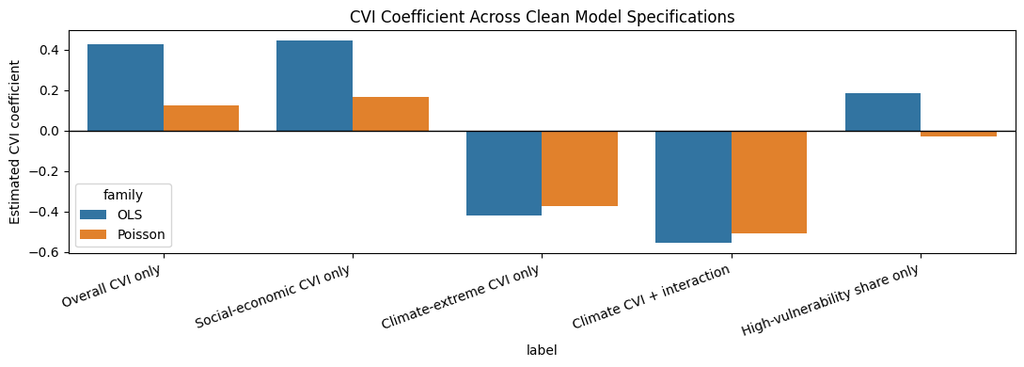

```
Quick read: if the CVI coefficient keeps a similar sign across these simpler models, the relationship is more interpretable than in the multicollinear extended model.
```